# Exploratory Data Analysis - Final Project

Christian Ibanez

2023-08-14

### Goal: The overall goal of this assignment is to explore the National Emissions Inventory database and see what it say about fine particulate matter pollution in the United states over the 10-year period 1999–2008.

#### Import the Datasets

```r
library("dplyr")
library("ggplot2")

# Get the directory where the R script is located
script_directory <- dirname(rstudioapi::getSourceEditorContext()$path)
# Set the working directory to the script's directory
setwd(script_directory)

## This first line will likely take a few seconds. Be patient!
NEI <- readRDS("./Data/summarySCC_PM25.rds")
SCC <- readRDS("./Data/Source_Classification_Code.rds")
```

#### 1. Have total emissions from PM2.5 decreased in the United States from 1999 to 2008? Using the base plotting system, make a plot showing the total PM2.5 emission from all sources for each of the years 1999, 2002, 2005, and 2008.

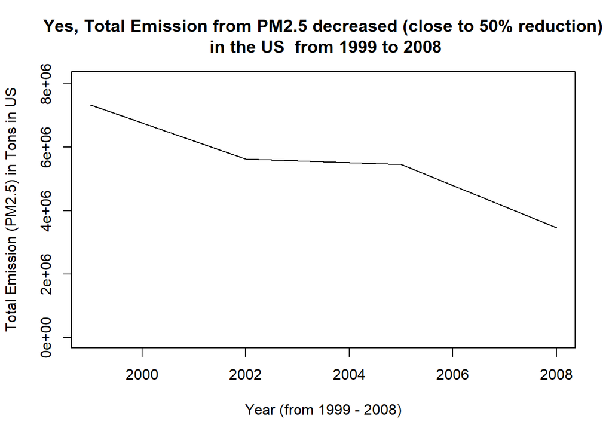

```r
#Using Base Plotting System in R
# Plot the Total Emission per Year
# png(file = "./Plots/plot1.png", width = 800, height = 600, units = "px", pointsize = 12)


df_grp_year_sum <- aggregate(Emissions ~ year, data = NEI, FUN = sum)

plot(df_grp_year_sum$year, df_grp_year_sum$Emissions, type = "l",
     ylab = "Total Emission (PM2.5) in Tons in US",
     xlab = "Year (from 1999 - 2008)",
     main = "Yes, Total Emission from PM2.5 decreased (close to 50% reduction)\n in the US  from 1999 to 2008",
     ylim = c(0, max(df_grp_year_sum$Emissions) * 1.1),
     # las = 1
     ) # Set the minimum y value to 0
```

```r
#dev.off()
```

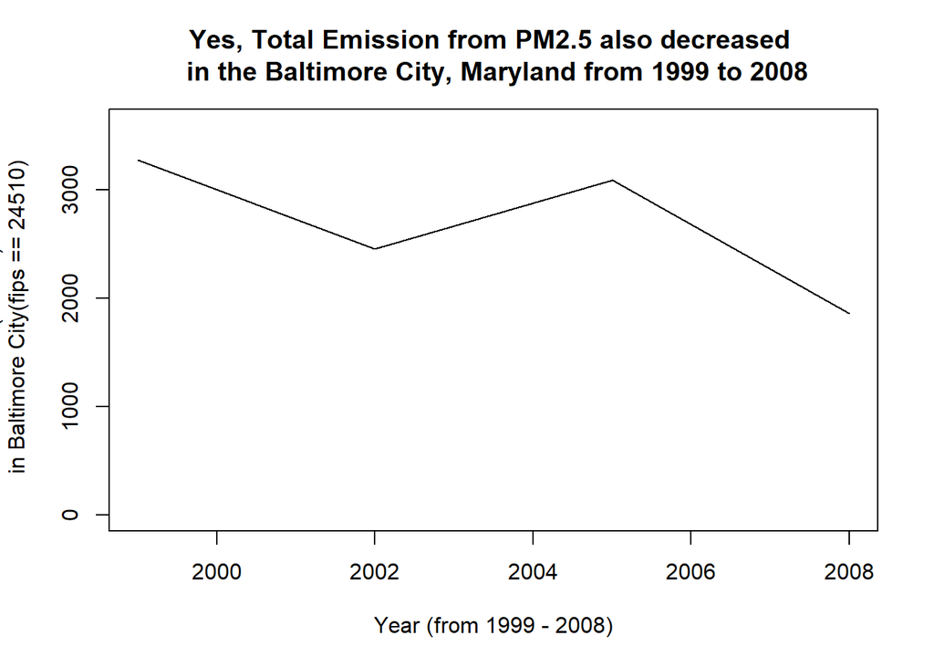

```r
# png(file = "./Plots/plot2.png", width = 800, height = 600, units = "px", pointsize = 12)

NEI_24510 <- filter(NEI,fips == "24510")
df_grp_year_sum_24510 <- aggregate(Emissions ~ year, data = NEI_24510, FUN = sum)

plot(df_grp_year_sum_24510$year, df_grp_year_sum_24510$Emissions, type = "l",
     ylab = "Total Emission (PM2.5) in Tons \n in Baltimore City(fips == 24510)",
     xlab = "Year (from 1999 - 2008)",
     main = "Yes, Total Emission from PM2.5 also decreased \n in the Baltimore City, Maryland from 1999 to 2008",
     ylim = c(0, max(df_grp_year_sum_24510$Emissions) * 1.1)) # Set the minimum y value to 0
```

```r
# dev.off()
```

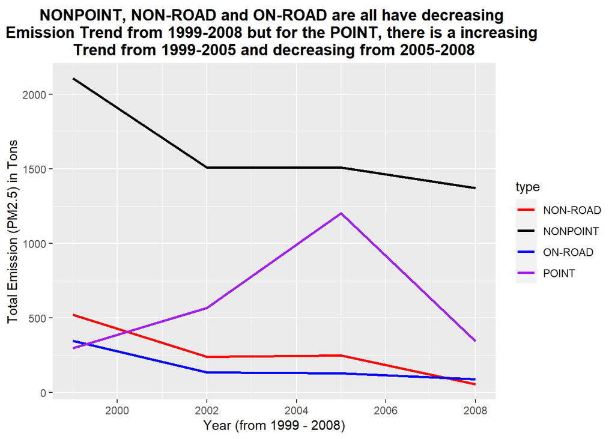

```r
# png(file = "./Plots/plot3.png", width = 800, height = 600, units = "px", pointsize = 12)

NEI_24510 <- filter(NEI,fips == "24510")
#df_grp_year_sum_24510 <- aggregate(Emissions ~ year, data = NEI_24510, FUN = sum)

df_grp_year_type_sum_24510 = NEI_24510 %>% group_by(year, type)  %>%
  summarise(total_Emissions = sum(Emissions),
            .groups = 'drop')

ggplot(df_grp_year_type_sum_24510,
       aes(x = year, y = total_Emissions, group = type, color = type)) +
  geom_line(size = 1) +
  xlab("Year (from 1999 - 2008)") +
  ylab("Total Emission (PM2.5) in Tons") +
  scale_color_manual(values = c("red", "black", "blue", "purple")) +
  ggtitle("NONPOINT, NON-ROAD and ON-ROAD are all have decreasing \nEmission Trend from 1999-2008 but for the POINT, there is a increasing \nTrend from 1999-2005 and decreasing from 2005-2008") +
  theme(plot.title = element_text(hjust = 0.5, vjust = 0.5, face = "bold"))
```

```r
# dev.off()
```

### 4. Across the United States, how have emissions from coal combustion-related sources changed from 1999–2008?

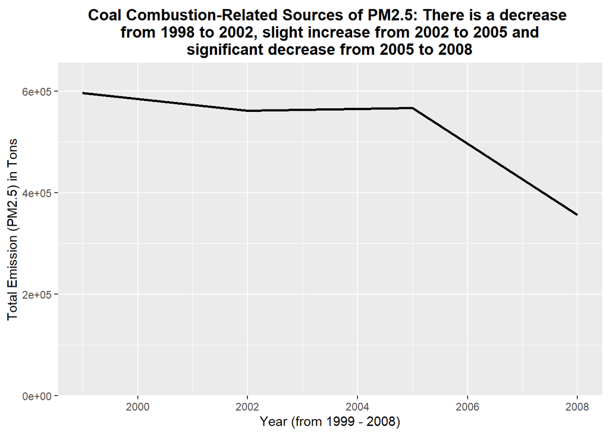

```r
# png(file = "./Plots/plot4.png", width = 800, height = 600, units = "px", pointsize = 12)

merged_NEI_SCC <- left_join(NEI, SCC, by = "SCC")
#View(merged_NEI_SCC[grepl("Coal", merged_NEI_SCC$Short.Name), ])
merged_NEI_SCC_Coal <- merged_NEI_SCC[grepl("Coal", merged_NEI_SCC$Short.Name), ]


merged_NEI_SCC_Coal_grp_year_sum = merged_NEI_SCC_Coal %>% group_by(year)  %>%
  summarise(total_Emissions = sum(Emissions),
            .groups = 'drop')

ggplot(merged_NEI_SCC_Coal_grp_year_sum, aes(x=year, y=total_Emissions)) +
  geom_line(size = 1) +
  ylab("Total Emission (PM2.5) in Tons") +
  xlab("Year (from 1999 - 2008)") +
  labs(title = "Coal Combustion-Related Sources of PM2.5: There is a decrease \n from 1998 to 2002, slight increase from 2002 to 2005 and \nsignificant decrease from 2005 to 2008") + # add a chart title
  theme(plot.title = element_text(hjust = 0.5, vjust = 0.5, face = "bold"))  + # center the title horizontally and vertically
  # Customize y-axis
  scale_y_continuous(
                    # labels = comma,
                     limits = c(0, max(merged_NEI_SCC_Coal_grp_year_sum$total_Emissions) * 1.1), # set the maximum limit 10% higher than the max value of y
                     expand = c(0, 0.05)) # remove white space at the top of the chart
```

```r
# dev.off()
```

### 5. How have emissions from motor vehicle sources changed from 1999–2008 in Baltimore City

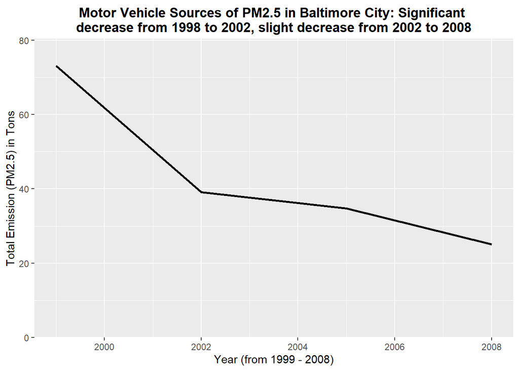

```r
# png(file = "./Plots/plot5.png", width = 800, height = 600, units = "px", pointsize = 12)

merged_NEI_SCC <- left_join(NEI, SCC, by = "SCC")

merged_NEI_SCC_24510 <- filter(merged_NEI_SCC,fips == "24510")
merged_NEI_SCC_24510_Motor <- merged_NEI_SCC_24510[grepl("Vehicles|Motor", merged_NEI_SCC_24510$Short.Name), ]

merged_NEI_SCC_24510_Motor_grp_year_sum = merged_NEI_SCC_24510_Motor %>% group_by(year)  %>%
  summarise(total_Emissions = sum(Emissions),
            .groups = 'drop')

ggplot(merged_NEI_SCC_24510_Motor_grp_year_sum, aes(x=year, y=total_Emissions)) +
  geom_line(size = 1) +
  ylab("Total Emission (PM2.5) in Tons") +
  xlab("Year (from 1999 - 2008)") +
  labs(title = "Motor Vehicle Sources of PM2.5 in Baltimore City: Significant \ndecrease from 1998 to 2002, slight decrease from 2002 to 2008") + # add a chart title
  theme(plot.title = element_text(hjust = 0.5, vjust = 0.5, face = "bold"))  + # center the title horizontally and vertically
  # Customize y-axis
  scale_y_continuous(
      # labels = comma,
                     limits = c(0, max(merged_NEI_SCC_24510_Motor_grp_year_sum$total_Emissions) * 1.1), # set the maximum limit 10% higher than the max value of y
                     expand = c(0, 0.05)) # remove white space at the top of the chart
```

```r
# dev.off()
```

#### 6. Compare emissions from motor vehicle sources in Baltimore City with emissions from motor vehicle sources in Los Angeles County, California (fips == “06037” fips == “06037”). Which city has seen greater changes over time in motor vehicle emissions?

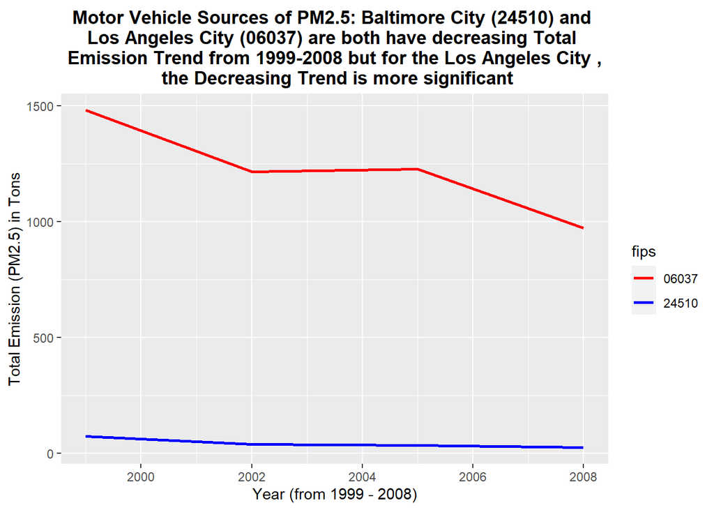

```r
# png(file = "./Plots/plot6.png", width = 800, height = 600, units = "px", pointsize = 12)

merged_NEI_SCC_Motor <- merged_NEI_SCC[grepl("Vehicles|Motor", merged_NEI_SCC$Short.Name), ]
merged_NEI_SCC_Motor_06037_24510 <- merged_NEI_SCC_Motor[grepl("06037|24510", merged_NEI_SCC_Motor$fips), ]


merged_NEI_SCC_Motor_06037_24510_year_sum = merged_NEI_SCC_Motor_06037_24510 %>% group_by(year, fips)  %>%
  summarise(total_Emissions = sum(Emissions),
            .groups = 'drop')

ggplot(merged_NEI_SCC_Motor_06037_24510_year_sum,
       aes(x = year, y = total_Emissions, group = fips, color = fips)) +
  geom_line(size = 1) +
  xlab("Year (from 1999 - 2008)") +
  ylab("Total Emission (PM2.5) in Tons") +
  scale_color_manual(values = c("red", "blue")) +
  ggtitle("Motor Vehicle Sources of PM2.5: Baltimore City (24510) and \nLos Angeles City (06037) are both have decreasing Total \n Emission Trend from 1999-2008 but for the Los Angeles City , \n the Decreasing Trend is more significant") +
  theme(plot.title = element_text(hjust = 0.5, vjust = 0.5, face = "bold"))
```

```r
# dev.off()
```